# Project Python Foundations: FoodHub Data Analysis

#### Observation of restaurants

- Top three restaurants had nearly 25% of the orders
- Top five restaurants had a third of the orders
- A few restaurants dominate based on the number of order

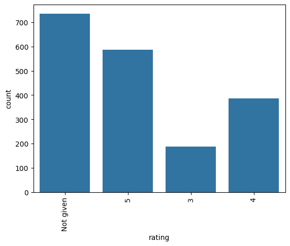

```python
#observation of rating
sns.countplot(data=data,x='rating')
plt.xticks(rotation=90)
plt.show()
```

```python
print(data['rating'].value_counts())
```

```
Not given    736
5            588
4            386
3            188
Name: rating, dtype: int64
```

- Nearly 39% of `rating` has value `Not given`
- Rating of 5 had the highest number
- Rating of 4 and 3 combined had nearly the same number of orders as the 5s

### **Question 7**: Which are the top 5 restaurants in terms of the number of orders received? [1 mark]

```python
data['restaurant_name'].value_counts().head(n=5)
```

```
Shake Shack                  219
The Meatball Shop            132
Blue Ribbon Sushi            119
Blue Ribbon Fried Chicken     96
Parm                          68
Name: restaurant_name, dtype: int64
```

#### Observations:

- Top 5 restaurants are 33% of the total
- Shake Shack has the most number of orders by far

### **Question 8**: Which is the most popular cuisine on weekends? [1 mark]

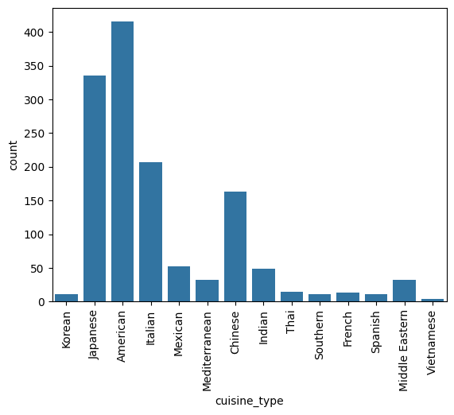

```
American          415
Japanese          335
Italian           207
Chinese           163
Mexican            53
Indian             49
Mediterranean      32
Middle Eastern     32
Thai               15
French             13
Korean             11
Southern           11
Spanish            11
Vietnamese          4
Name: cuisine_type, dtype: int64
```

```
1351
```

```python
sns.countplot(data=data.loc[data['day_of_the_week']=="Weekend"],x='cuisine_type')
plt.xticks(rotation=90)
plt.show()

weekend_cuisines = data.loc[data['day_of_the_week']=="Weekend",'cuisine_type']
print(weekend_cuisines.value_counts(dropna=False))
weekend_cuisines.count()
```

#### Observations:

- American is the most popular
- The top four (American, Japanese, Italian, Chinese) dominate both weekend and weekday
- The top four cuisines have 83% of the weekend orders

### **Question 9**: What percentage of the orders cost more than 20 dollars? [2 marks]

```python
order_count_greater_than_20 = data.loc[data['cost_of_the_order']>20].shape[0]
format(order_count_greater_than_20/data['cost_of_the_order'].count(), ".0%")
```

```
'29%'
```

#### Observations:

29% of the orders cost more than \$20

### **Question 10**: What is the mean order delivery time? [1 mark]

```python
data['delivery_time'].mean()
```

```
24.161749209694417
```

#### Observations:

- Mean order delivery time is 24

### **Question 11:** The company has decided to give 20% discount vouchers to the top 3 most frequent customers. Find the IDs of these customers and the number of orders they placed. [1 mark]

```python
data['customer_id'].value_counts().head(3)
```

```
52832    13
47440    10
83287     9
Name: customer_id, dtype: int64
```

### **Question 12**: Perform a multivariate analysis to explore relationships between the important variables in the dataset. (It is a good idea to explore relations between numerical variables as well as relations between numerical and categorical variables) [10 marks]

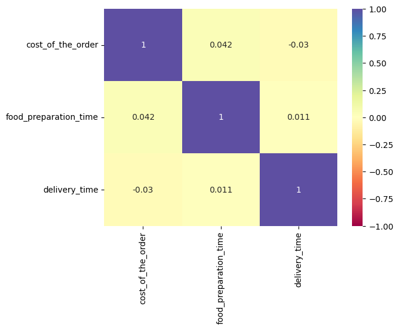

```python
# plt.figure(figsize=(10,5))
data_without_id_columns= data.drop(columns=["order_id", "customer_id"])
sns.heatmap(data_without_id_columns.corr(),annot=True,cmap='Spectral',vmin=-1,vmax=1)
plt.show()
```

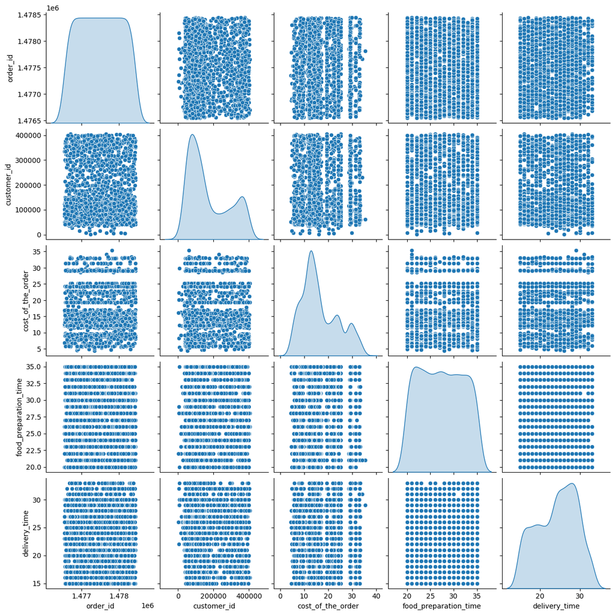

```python
sns.pairplot(data, diag_kind="kde");
```

- Weak correlation between cost, preparation time, and delivery time

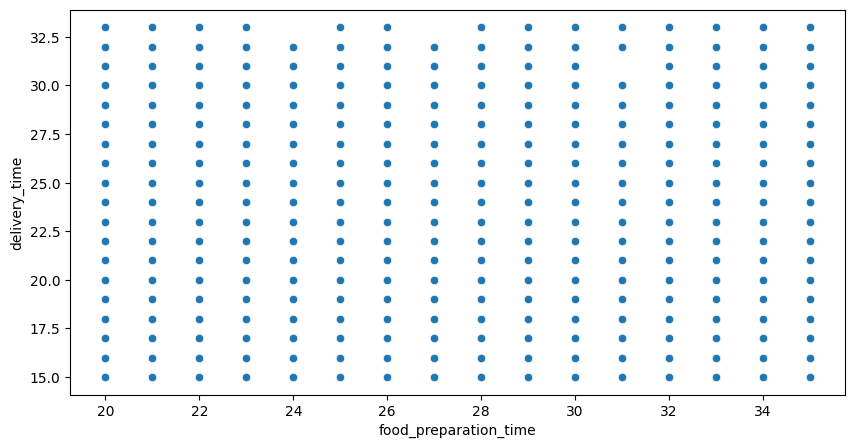

```python
plt.figure(figsize=(10,5))
sns.scatterplot(data=data,x='food_preparation_time',y='delivery_time')
plt.show()
```

When comparing food preparation time to delivery time, no pattern is revealed

#### Cuisine

**Lets check relationship between cuisine and cost of the order**

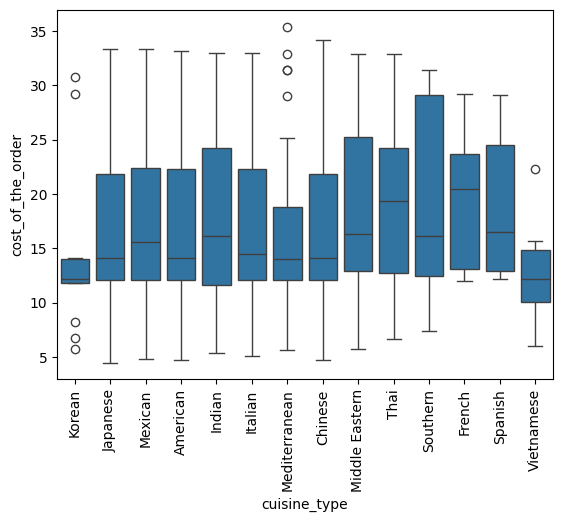

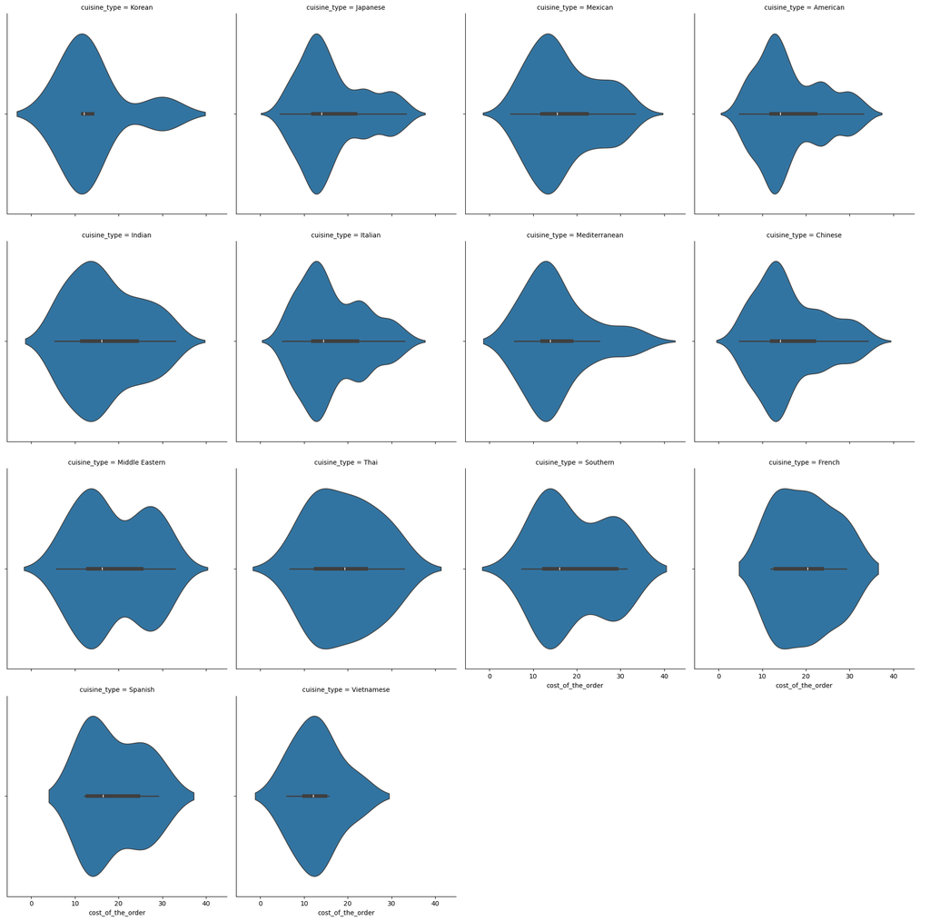

```python
sns.boxplot(data=data,x='cuisine_type',y='cost_of_the_order')
plt.xticks(rotation=90)
plt.show()

# Dispersion of price in every region
sns.catplot(x='cost_of_the_order',
            col='cuisine_type',
            data=data,
            col_wrap=4,
            kind="violin")
plt.show()
```

- Southern has the biggest IRQ range and Korean has the smallest
- French has the highest average cost per order
- Vietnamese has the least average cost per order

**Lets check relationship between cuisine and food preparation time**

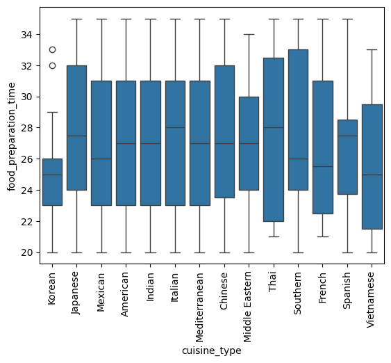

```python
sns.boxplot(data=data,x='cuisine_type',y='food_preparation_time')
plt.xticks(rotation=90)
plt.show()
```

- Food takes between 25 and 28 minutes to prepare
- Vietnamese and Korean take the shortest time to prepare
- Italian and Thai take the longest to prepare

**Lets check the relationship between cuisine and delivery time**

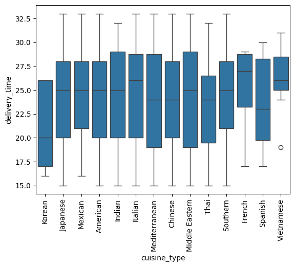

```python
sns.boxplot(data=data,x='cuisine_type',y='delivery_time')
plt.xticks(rotation=90)
plt.show()
```

- Generally Japanese, American, Italian, Mediteranean, Middle Easter, Southern can have delivery times between the 15 (min) and 32 (max).
- French on average has the longest delivery times
- Korean has the shortest delivery time
- Japanese, American, Italian, Indian, Southern have similar average delivery times

**Lets check the relationship between cuisine and the day of the week**

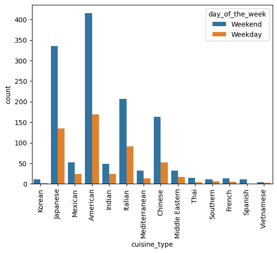

```python
sns.countplot(data=data,x='cuisine_type',hue='day_of_the_week')
plt.xticks(rotation=90)
plt.show()
```

- The orders seem to be proportional between each of the cuisine types regardless of the day of the week.

**Lets compare the cusisine type to cost of the order and consider the day of the week**

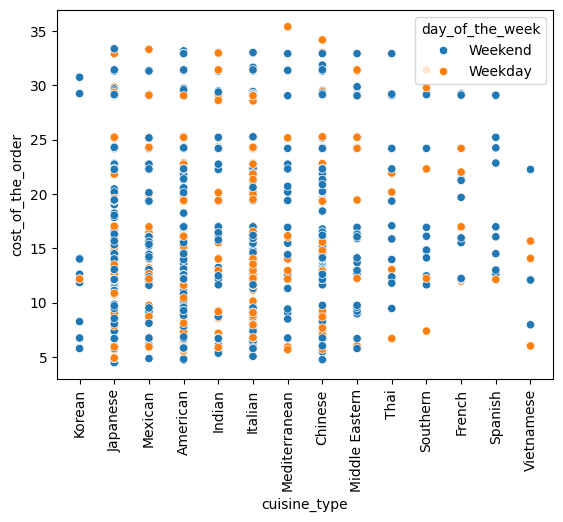

```python
sns.scatterplot(data=data, x="cuisine_type", y="cost_of_the_order", hue="day_of_the_week")
plt.xticks(rotation=90)
plt.show()
```

There may be a lot of overlapping data, so we may want to use a stripplot

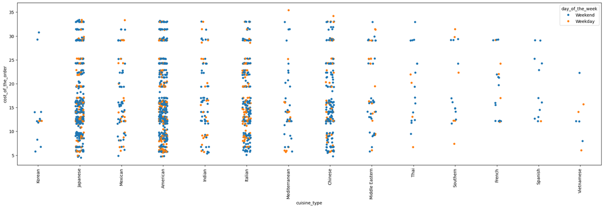

```python
plt.figure(figsize=(25, 7)) # To resize the plot
sns.stripplot(data = data, x = "cuisine_type", y = "cost_of_the_order", hue="day_of_the_week"
            )
plt.xticks(rotation=90);
```

### **Question 13:** The company wants to provide a promotional offer in the advertisement of the restaurants. The condition to get the offer is that the restaurants must have a rating count of more than 50 and the average rating should be greater than 4. Find the restaurants fulfilling the criteria to get the promotional offer. [3 marks]

Let's begin by keeping the data that is rated

```python
# remove the orders that were 'Not Rated'
rated_data = data.loc[data['rating'] != 'Not given'].reset_index()
# convert the ratings to an int
rated_data['order_rating'] = rated_data.loc[:,'rating'].astype(int)
rated_data.head()
```

|  | index | order_id | customer_id | restaurant_name | cuisine_type | cost_of_the_order | day_of_the_week | rating | food_preparation_time | delivery_time | order_rating |
| --- | --- | --- | --- | --- | --- | --- | --- | --- | --- | --- | --- |
| 0 | 2 | 1477070 | 66393 | Cafe Habana | Mexican | 12.23 | Weekday | 5 | 23 | 28 | 5 |
| 1 | 3 | 1477334 | 106968 | Blue Ribbon Fried Chicken | American | 29.20 | Weekend | 3 | 25 | 15 | 3 |
| 2 | 4 | 1478249 | 76942 | Dirty Bird to Go | American | 11.59 | Weekday | 4 | 25 | 24 | 4 |
| 3 | 5 | 1477224 | 147468 | Tamarind TriBeCa | Indian | 25.22 | Weekday | 3 | 20 | 24 | 3 |
| 4 | 7 | 1477859 | 89574 | Barbounia | Mediterranean | 5.97 | Weekday | 3 | 33 | 30 | 3 |

Next, let's get restrauants who have more than 50 ratings

```python
# create a variable that contains the restraurants and their rating counts
restaurant_rating_count = rated_data.groupby(['restaurant_name'])['order_rating'].count().reset_index()
# rename the rating column to rating_counts and sort them in descending order
restaurant_rating_count.rename(columns={'order_rating':'rating_counts'},inplace=True)
# restaurant_rating_count.sort_values(ascending=False, by= 'rating_counts')
# get list of restaurant with rating greater than 50
restaurant_rating_50 = restaurant_rating_count[restaurant_rating_count['rating_counts']>50]
restaurant_rating_50
```

|  | restaurant_name | rating_counts |
| --- | --- | --- |
| 16 | Blue Ribbon Fried Chicken | 64 |
| 17 | Blue Ribbon Sushi | 73 |
| 117 | Shake Shack | 133 |
| 132 | The Meatball Shop | 84 |

Now let's get the restrauants who have an average rating greater than 4

```python
restaurant_average_rating = rated_data.groupby(['restaurant_name'])[['order_rating']].mean().reset_index()
restaurant_average_rating.rename(columns={'order_rating':'avg_rating'},inplace=True)
# get the list of restraurants who have a rating greater than 4
rating_greater_4 = restaurant_average_rating[restaurant_average_rating['avg_rating']>4]
rating_greater_4
```

|  | restaurant_name | avg_rating |
| --- | --- | --- |
| 0 | 'wichcraft | 5.000000 |
| 1 | 12 Chairs | 4.500000 |
| 3 | 67 Burger | 5.000000 |
| 4 | Amma | 4.500000 |
| 6 | Anjappar Chettinad | 5.000000 |
| ... | ... | ... |
| 149 | Yama 49 | 5.000000 |
| 150 | Yama Japanese Restaurant | 4.500000 |
| 153 | da Umberto | 5.000000 |
| 154 | ilili Restaurant | 4.153846 |
| 155 | indikitch | 4.500000 |

110 rows × 2 columns

We have a list of restaurants that have more than 50 ratings (in a dataframe named `restaurant_rating_50`) And we have a list of restraunts that have an average rating greater than 4 (in a dataframe named `rating_greater_4`)

Merge both datasets, and create a combined view on the basis of average rating and rating counts

```python
promo_restaurants = restaurant_rating_50.merge(rating_greater_4, on = 'restaurant_name', how = 'inner')
promo_restaurants
```

|  | restaurant_name | rating_counts | avg_rating |
| --- | --- | --- | --- |
| 0 | Blue Ribbon Fried Chicken | 64 | 4.328125 |
| 1 | Blue Ribbon Sushi | 73 | 4.219178 |
| 2 | Shake Shack | 133 | 4.278195 |
| 3 | The Meatball Shop | 84 | 4.511905 |

#### Observations:

- 4 restaurants had more than 50 ratings
- 110 restaurants had a rating above 4
- 4 restaurants qualified for the promotion:
  - Blue Ribbon Fried Chicken
  - Blue Ribbon Sushi
  - Shake Shack
  - The Meatball Shop

### **Question 14:** The company charges the restaurant 25% on the orders having cost greater than 20 dollars and 15% on the orders having cost greater than 5 dollars. Find the net revenue generated by the company across all orders. [3 marks]

Create a function with conditional statements (for each category, 25%, 15% and 0%(else condition) and mention the revenue for each condition.

```python
def calculate_revenue(cost_of_the_order):
    if cost_of_the_order > 20:
        return cost_of_the_order * .25
    elif cost_of_the_order > 5:
        return cost_of_the_order * .15
    else:
        return 0

# test the function, numbers should match
print(20*.15, calculate_revenue(20))
print(22*.25, calculate_revenue(22))
print(5*0, calculate_revenue(5))
```

```
3.0 3.0
5.5 5.5
0 0
```

Apply the function to the cost_of_the_order column to calculate the revenue, sum the value in a revenue column.

```python
data['revenue'] = data['cost_of_the_order'].map(lambda x: calculate_revenue(x))
# sanity check the revenue column with the cost_of_order in the first two rows
print(30.75*.25, calculate_revenue(30.75))
print(12.08*.15, calculate_revenue(12.08))
data
```

```
7.6875 7.6875
1.8119999999999998 1.8119999999999998
```

|  | order_id | customer_id | restaurant_name | cuisine_type | cost_of_the_order | day_of_the_week | rating | food_preparation_time | delivery_time | revenue |
| --- | --- | --- | --- | --- | --- | --- | --- | --- | --- | --- |
| 0 | 1477147 | 337525 | Hangawi | Korean | 30.75 | Weekend | Not given | 25 | 20 | 7.6875 |
| 1 | 1477685 | 358141 | Blue Ribbon Sushi Izakaya | Japanese | 12.08 | Weekend | Not given | 25 | 23 | 1.8120 |
| 2 | 1477070 | 66393 | Cafe Habana | Mexican | 12.23 | Weekday | 5 | 23 | 28 | 1.8345 |
| 3 | 1477334 | 106968 | Blue Ribbon Fried Chicken | American | 29.20 | Weekend | 3 | 25 | 15 | 7.3000 |
| 4 | 1478249 | 76942 | Dirty Bird to Go | American | 11.59 | Weekday | 4 | 25 | 24 | 1.7385 |
| ... | ... | ... | ... | ... | ... | ... | ... | ... | ... | ... |
| 1893 | 1476701 | 292602 | Chipotle Mexican Grill $1.99 Delivery | Mexican | 22.31 | Weekend | 5 | 31 | 17 | 5.5775 |
| 1894 | 1477421 | 397537 | The Smile | American | 12.18 | Weekend | 5 | 31 | 19 | 1.8270 |
| 1895 | 1477819 | 35309 | Blue Ribbon Sushi | Japanese | 25.22 | Weekday | Not given | 31 | 24 | 6.3050 |
| 1896 | 1477513 | 64151 | Jack's Wife Freda | Mediterranean | 12.18 | Weekday | 5 | 23 | 31 | 1.8270 |
| 1897 | 1478056 | 120353 | Blue Ribbon Sushi | Japanese | 19.45 | Weekend | Not given | 28 | 24 | 2.9175 |

1898 rows × 10 columns

The sum of the revenue column will give the total revenue

```python
data['revenue'].sum()
```

```
6166.303
```

#### Observations:

- Of the 1898 orders, the revenue was 6166.30.
- The revenue for the average order was

```python
data['revenue'].mean().round(2)
```

```
3.25
```

### **Question 15:** The company wants to analyze the total time required to deliver the food. What percentage of orders take more than 60 minutes to get delivered from the time the order is placed? (The food has to be prepared and then delivered.) [2 marks]

Create a column with the total food preparation time and the delivery time

```python
data['total_time'] = data.apply(lambda x: x['food_preparation_time'] + x['delivery_time'] , axis=1)
# sanity check the result
data.loc[:, ['food_preparation_time', 'delivery_time', 'total_time']]
```

|  | food_preparation_time | delivery_time | total_time |
| --- | --- | --- | --- |
| 0 | 25 | 20 | 45 |
| 1 | 25 | 23 | 48 |
| 2 | 23 | 28 | 51 |
| 3 | 25 | 15 | 40 |
| 4 | 25 | 24 | 49 |
| ... | ... | ... | ... |
| 1893 | 31 | 17 | 48 |
| 1894 | 31 | 19 | 50 |
| 1895 | 31 | 24 | 55 |
| 1896 | 23 | 31 | 54 |
| 1897 | 28 | 24 | 52 |

1898 rows × 3 columns

Get the number of rows where the total time is greater than 60 and divide it by the total number of rows

```python
orders_greaterthan_60 = data[data.total_time > 60].shape[0]
np.round(orders_greaterthan_60/data.shape[0], 2)
```

```
0.11
```

Determine if correlations between total time and other variables

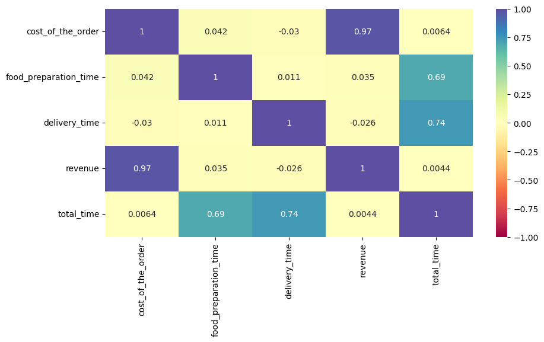

```python
plt.figure(figsize=(10,5))
data_without_id_columns= data.drop(columns=["order_id", "customer_id"])
sns.heatmap(data_without_id_columns.corr(),annot=True,cmap='Spectral',vmin=-1,vmax=1)
plt.show()
```

#### Observations:

- 11 percent of the orders take more than 60 minutes considering the time it takes to prepare food and then delivered
- Total time for the order is highly correlated to delivery time

### **Question 16:** The company wants to analyze the delivery time of the orders on weekdays and weekends. How does the mean delivery time vary during weekdays and weekends? [2 marks]

Get the mean delivery time for all of the days

```python
data.loc[:,'delivery_time'].mean()
```

```
24.161749209694417
```

Get the mean delivery time for just the weekends

```python
data.groupby(['day_of_the_week'])[['delivery_time']].mean()
```

| day_of_the_week | delivery_time |
| --- | --- |
| Weekday | 28.340037 |
| Weekend | 22.470022 |

View the boxpot to visually inspect the delivery time for the weekend and weekday

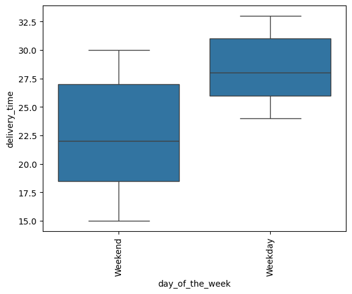

```python
sns.boxplot(data=data,x='day_of_the_week',y='delivery_time')
plt.xticks(rotation=90)
plt.show()
```

#### Observations:

- Weekend deliveries are about 6 minutes faster than weekdays
- There are more orders on weekends with faster deliveries than weekdays
- Weekday deliveries are 4 minutes longer than the average delivery
- Weekend deliveries are 2 minutes faster than the average delivery

### Conclusion and Recommendations

### **Question 17:** What are your conclusions from the analysis? What recommendations would you like to share to help improve the business? (You can use cuisine type and feedback ratings to drive your business recommendations.) [6 marks]

### Conclusions:

- Weekends dominate over weekday: Weekend is 71%; weekday is 28%
- Weekend deliveries are faster than weekday deliveries
- Shake Shack has significant share of about 12% of the orders
- The top four cuisines (American, Japanese, Italian, Chinese) dominate
- The top four cuisines have 83% of the weekend orders
- nearly 40% of ratings are not given
- The same restaurants that qualified for the promotion are the top four restaurants for orders
- 11% of orders take an hour or more to arrive
- 29% of orders are over $20

### Recommendations:

Grow the business on weekdays

- The service has capacity to grow on weekdays as suggested by the disparity of weekends dominating the number of orders
- Promote the promotional offer to the top restaurants on weekdays

Improve delivery times on weekdays

- Weekdays have an opportunity to grow. Suggest working closely with delivery firms/individuals to speed up weekday delivery
- Provide offers for weekday buyers near to restarurants

Grow the business with cuisines outside the top 4

- Highlight lesser served restaurants as alternative choices
- Target customers who have alternative restaurants nearby (reducing delivery time) with promotion
- Reward customers who often use the service to try alternative restaurants

Increase ratings for order

- Provide incentives for new raters
- Follow up those who do not rate on receipt a few hours after their order is delivered

Increase order size

- Offer incentives to increase order size to over $20